# School leader and Gender Equity

Ama Owusu-Darko

2025-08-31

Load R packages

Setup up file paths

Load Pre-work data set and save it as the dataframe “school_leaders_df

```r
school_leaders_df <- readxl::read_excel(here::here("raw_data/Pre-work Dataset.xlsx"))
```

Data Preparation

```r
#Creating a subset of the data
professions_df <- school_leaders_df[,c(1,8,42:50)] |>
  tidyr::pivot_longer(
    cols = starts_with("What kinds of careers do you think are suitable for students?"),
    names_to = "Professions",
    values_to = "Suitable_Gender"
  )


# Cleaning up names of profession
professions_df$Professions <- stringr::str_replace(professions_df$Professions,
"What kinds of careers do you think are suitable for students?", "" )

professions_df$Professions <- stringr::str_replace_all(professions_df$Professions,"[?\\n ]", "" )


#Separating data set for the school leader is a man

professions_df_male_school_leader <- professions_df |>
  dplyr::mutate(dplyr::across(c(1:3), as.factor)) |>
  dplyr::filter(`What is your gender?` == "Man") |>
  dplyr::count(`What is your gender?`,Professions, Suitable_Gender,
               name = "Count") |>
  dplyr::arrange(Professions) |>
  dplyr::mutate(Within_Group_percentage = round((Count/ 302)*100, 1))
# There are 302 male school leaders

#Separating data set for the school leader is a woman
professions_df_female_school_leader <- professions_df |>
  dplyr::mutate(dplyr::across(c(1:3), as.factor)) |>
  dplyr::filter(`What is your gender?` == "Woman")|>
  dplyr::count(`What is your gender?`, Professions, Suitable_Gender,
               name = "Count") |>
  dplyr::arrange(Professions) |>
  dplyr::mutate(Within_Group_percentage = round((Count/ 183)*100, 1))
# There are 183 female school leaders

professions_df_female_school_leader
```

```
## # A tibble: 36 × 5
##    `What is your gender?` Professions                      Suitable_Gender Count
##    <fct>                  <fct>                            <chr>           <int>
##  1 Woman                  [Airhostess]                     Both               52
##  2 Woman                  [Airhostess]                     Boys                8
##  3 Woman                  [Airhostess]                     Girls             113
##  4 Woman                  [Airhostess]                     NA                 10
##  5 Woman                  [Artist]                         Both               94
##  6 Woman                  [Artist]                         Boys               64
##  7 Woman                  [Artist]                         Girls              20
##  8 Woman                  [Artist]                         NA                  5
##  9 Woman                  [Caregiverforchildren/theelderl… Both               53
## 10 Woman                  [Caregiverforchildren/theelderl… Boys                3
## # ℹ 26 more rows
## # ℹ 1 more variable: Within_Group_percentage <dbl>
```

```r
professions_df_male_school_leader
```

```
## # A tibble: 36 × 5
##    `What is your gender?` Professions                      Suitable_Gender Count
##    <fct>                  <fct>                            <chr>           <int>
##  1 Man                    [Airhostess]                     Both              125
##  2 Man                    [Airhostess]                     Boys               15
##  3 Man                    [Airhostess]                     Girls             144
##  4 Man                    [Airhostess]                     NA                 18
##  5 Man                    [Artist]                         Both              195
##  6 Man                    [Artist]                         Boys               70
##  7 Man                    [Artist]                         Girls              28
##  8 Man                    [Artist]                         NA                  9
##  9 Man                    [Caregiverforchildren/theelderl… Both              121
## 10 Man                    [Caregiverforchildren/theelderl… Boys                6
## # ℹ 26 more rows
## # ℹ 1 more variable: Within_Group_percentage <dbl>
```

#### Creating a Gender versus Professions Percent stacked bar chart

To display the results of which genders the school leaders perceive to be suitable for the different professions.

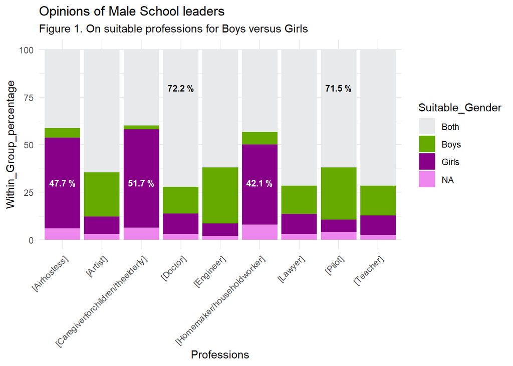

```r
ggplot2::ggplot(professions_df_male_school_leader, aes(fill = Suitable_Gender,
                  x = Professions, y=Within_Group_percentage ))+
    geom_bar(position="stack", stat="identity")+
scale_fill_manual(values = c("#e8e9eb", "#66aa00", "#808", "#e8e"))+
  theme_minimal()+
    theme(axis.text.x = element_text(angle = 45, hjust = 1))+
 labs(title="Opinions of Male School leaders",
      subtitle = "Figure 1. On suitable professions for Boys versus Girls") + annotate("text", x = c(1,3, 6), y = c(30),
label = c( paste(professions_df_male_school_leader[3,5],"%"),
          paste(professions_df_male_school_leader[11,5],"%"),
          paste(professions_df_male_school_leader[23,5],"%")), color="white",
size=3 , angle=0, fontface="bold")+

  annotate("text", x = c(4,8), y = c(80),
label = c( paste(professions_df_male_school_leader[13,5],"%"),
          paste(professions_df_male_school_leader[25,5],"%")), color="black",
size=3 , angle=0, fontface="bold")
```

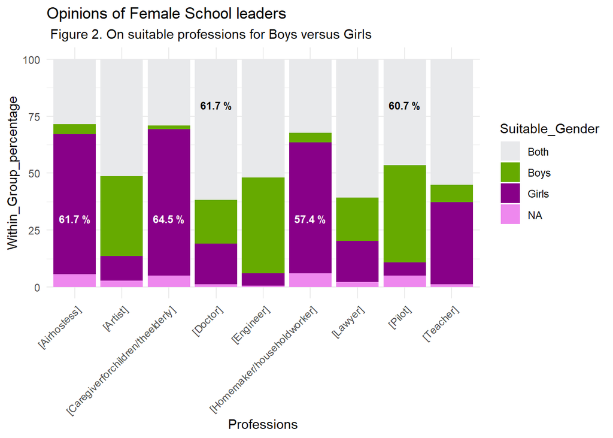

```r
ggplot2::ggplot(professions_df_female_school_leader, aes(fill = Suitable_Gender,
                                                         x = Professions, y= Within_Group_percentage ))+
    geom_bar(position="stack", stat="identity")+
scale_fill_manual(values = c("#e8e9eb", "#66aa00", "#808", "#e8e"))+
  theme_minimal()+
    theme(axis.text.x = element_text(angle = 45, hjust = 1))+
  labs(title="Opinions of Female School leaders",
       subtitle = " Figure 2. On suitable professions for Boys versus Girls")+ annotate("text", x = c(1,3, 6),
                                                          y = c(30),
label = c( paste(professions_df_female_school_leader[3,5],"%"),
          paste(professions_df_female_school_leader[11,5],"%"),
          paste(professions_df_female_school_leader[23,5],"%")), color="white",
size=3 , angle=0, fontface="bold")+
  annotate("text", x = c(4,8), y = c(80),
label = c( paste(professions_df_female_school_leader[13,5],"%"),
          paste(professions_df_female_school_leader[25,5],"%")), color="black",
size=3 , angle=0, fontface="bold")
```

The survey results showed that more female than male school leaders have segregated ideas about which careers are suited for each gender. For instance, as shown in Figures 1 and 2 above, the difference is skewed towards Female School leaders thinking girls are more suited to being Air hostesses (61.7%) versus 47.7% of Male School leaders.

#### What is the effect of school leaders being trained on gender within the last year?.

Focusing on the professions Air hostess and Pilot

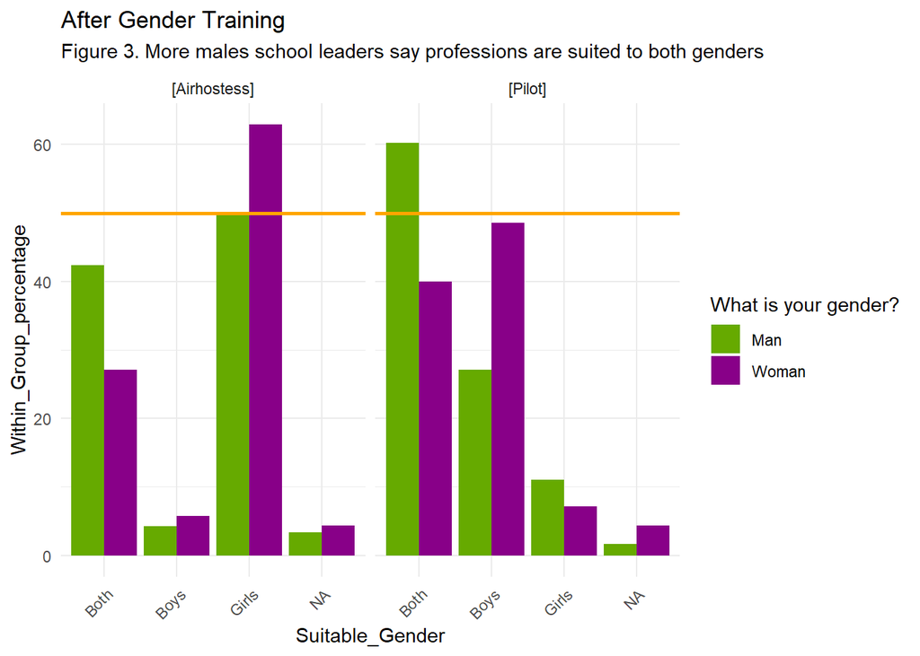

```r
#Separating data set for the school leader is a man whole receive gender
#training and the assessed professions are Air Hostess and Pilot

air_df_male_school_leader <- professions_df |>
  dplyr::filter(Professions %in% c("[Airhostess]", "[Pilot]")) |>
  dplyr::filter(
    `Have you received any training related to gender within the last 1 year?`
    == "Yes") |>
  dplyr::mutate(dplyr::across(c(1:3), as.factor)) |>
  dplyr::filter(`What is your gender?` == "Man") |>
  dplyr::count(`What is your gender?`,
`Have you received any training related to gender within the last 1 year?`,Professions,
Suitable_Gender, name = "Count") |>
  dplyr::arrange(Professions) |>
  dplyr::mutate(Within_Group_percentage = round((Count/ 118)*100, 1))



#Separating data set for the school leader is a woman and the assessed
# professions are Air Hostess and Pilot
air_df_female_school_leader <- professions_df |>
  dplyr::filter(Professions %in% c("[Airhostess]", "[Pilot]")) |>
  dplyr::filter(
    `Have you received any training related to gender within the last 1 year?`
    == "Yes") |>
  dplyr::mutate(dplyr::across(c(1:3), as.factor)) |>
  dplyr::filter(`What is your gender?` == "Woman")|>
  dplyr::count(`What is your gender?`,
`Have you received any training related to gender within the last 1 year?`,
Professions, Suitable_Gender, name = "Count") |>
  dplyr::arrange(Professions) |>
  dplyr::mutate(Within_Group_percentage = round((Count/70)*100, 1))



air_professions_df <- rbind(air_df_female_school_leader,
                            air_df_male_school_leader)


# Bar graph
ggplot2::ggplot(air_professions_df, aes(fill =  `What is your gender?`,
x = Suitable_Gender, y= Within_Group_percentage ))+

    geom_bar(position="dodge", stat="identity")+
scale_fill_manual(values = c( "#66aa00", "#808"))+
  theme_minimal()+
    theme(axis.text.x = element_text(angle = 45, hjust = 1))+
 labs(title="After Gender Training",
subtitle = "Figure 3. More males school leaders say professions are suited to both genders")+
  facet_wrap(~Professions)+
  geom_hline(yintercept=50, color="orange", linewidth=1)
```

The orange line shows the 50% mark. The results show that after gender training, about 60% of the male school leaders compared to 40% of female school leaders say both genders are suited to being Pilots. For the profession gender, even after being trained on gender, less than 50% of the school leaders both men and women said that both genders of students are suited to be Air hostesses.

Further research is needed to indicate if having the female sounding name “Air Hostess” instead of the gender neutral “Flight attendant” played a role in the choice the school leaders made.

Also, more research is needed to determine if increasing the frequency of the gender training to 3 times a year would increase the adoption of the message that careers should gender neutral.